# Deep Learning for Time Series

Recurrent Networks against ARIMA on Consumer Sentiment, with and without the Federal Funds Rate

Published

December 3, 2023

Modified

September 15, 2026

### Purpose

The preceding sections model the series in this study with linear time series methods. This section applies three recurrent neural networks, a simple recurrent network (`RNN`), a long short-term memory network (`LSTM`) (Hochreiter and Schmidhuber 1997) and a gated recurrent unit (`GRU`) (Cho et al. 2014), to the same forecasting task and compares them with the linear methods on the same test period. The target is the University of Michigan index of consumer sentiment, a monthly survey measure that the univariate sections did not cover and that is a plausible channel for the policy rate to reach households. Each network is trained on the previous twelve months of the index and, in a second version, on the previous twelve months of the index and of the Federal Funds Rate, so that the section also asks whether the policy rate helps predict sentiment. The benchmarks are the naive forecast, in which next month equals this month, an ARIMA model selected by AIC, and the same ARIMA with the policy rate as a regressor.

Recurrent networks are estimated by stochastic gradient descent from random starting values, so their results depend on the random seed. Every network is trained five times with different seeds and reported as a mean and standard deviation across seeds, and TensorFlow’s deterministic mode is enabled so that the page renders the same numbers each time.

## Data

The series is `UMCSENT`, monthly from January 1978, when the survey became monthly, to July 2023, 547 observations, merged with the Federal Funds Rate for the same months. The index is scaled so that the first quarter of 1966 equals 100.

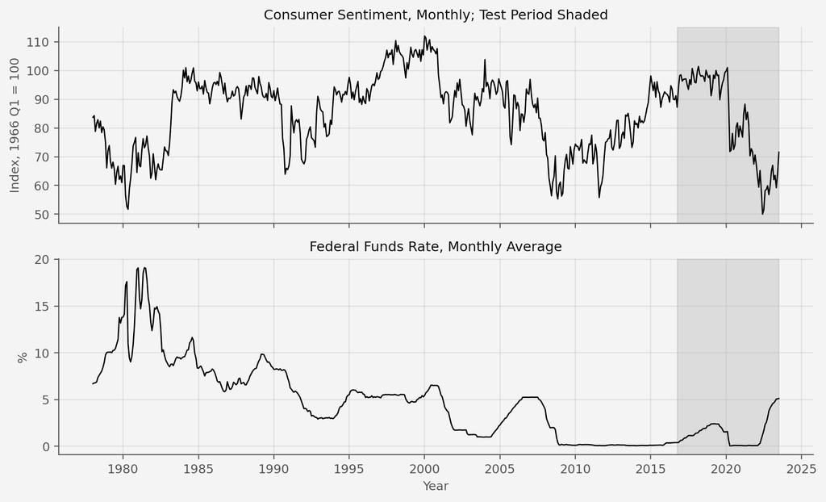

Consumer Sentiment, January 1978 to July 2023

| Statistic | Value |
| --- | --- |
| Observations | 547 |
| Mean | 85.1 |
| Standard deviation | 13.2 |
| Minimum | 50.0 in June 2022 |
| Maximum | 112.0 in January 2000 |
| ADF statistic, level (p-value) | -2.40 (0.143) |
| ADF statistic, first difference | -13.22 (< 0.001) |
| Autocorrelation at lag 1, 2, 3 | 0.952, 0.906, 0.871 |
| Correlation with the Federal Funds Rate, levels | -0.040 |
| Correlation of monthly changes | 0.029 |

Sentiment averages 85 with a standard deviation of 13, from a high of 112 in January 2000 to a low of 50 in June 2022. It is highly persistent: the autocorrelation is 0.95 at lag one and the ADF test does not reject a unit root (p = 0.14), while the first difference rejects it decisively. Its monthly changes have a standard deviation of about 4 index points. The correlation with the Federal Funds Rate is −0.04 in levels and 0.03 in monthly changes: there is no linear contemporaneous relationship between the two series to speak of, which sets a low prior for the multivariate networks.

The test period is the last 15% of the sample, the 82 months from October 2016 to July 2023, shaded in the figure. It contains the pandemic collapse of April 2020, a fall of 17 points in one month, the rebound, and the 2022 decline to the series’ all-time low. Everything before October 2016 is available for training.

## Design

```
Window length 12 months. Training samples 453 (of which 67 held out for early stopping), test samples 82.
```

Each training sample is a window of the twelve previous months and the target is the following month, so consecutive samples overlap by eleven months and the 465 training months yield 453 samples. The series are standardised with the mean and standard deviation of the training period only, so that no information from the test period enters the model. Each network has one recurrent layer of 32 units followed by a linear output, giving 1,121 parameters for the `RNN`, 4,385 for the `LSTM` and 3,393 for the `GRU` in the univariate version, and slightly more with the second input. Training minimises mean squared error with the Adam optimiser at a learning rate of 0.001 in batches of 32, for up to 300 epochs, and stops when the loss on the last 15% of the training samples has not improved for 15 epochs, restoring the weights from the best epoch. Forecasts are one step ahead on the test windows, without re-estimation. Errors are reported in index points after reversing the standardisation.

## Training

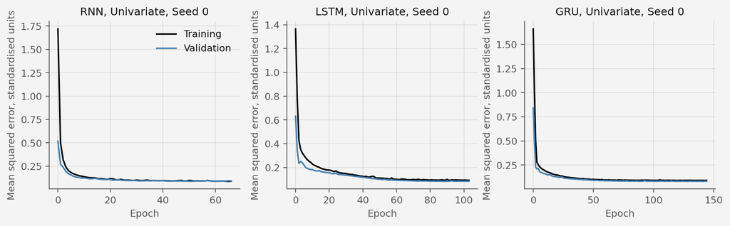

```
Epochs to early stopping, five seeds: RNN univariate: 47–75; RNN with FFR: 54–87; LSTM univariate: 103–166; LSTM with FFR: 106–162; GRU univariate: 111–177; GRU with FFR: 111–187
```

## One-Step-Ahead Results

One-Step-Ahead Forecast Errors on the Test Period, October 2016 to July 2023, 82 Months; Networks Averaged over Five Seeds; ARIMA Order Selected by AIC on the Training Period

| Model | Parameters | Test RMSE | s.d. across seeds | Test MAE | Training RMSE |
| --- | --- | --- | --- | --- | --- |
| RNN, univariate | 1121 | 4.538 | 0.016 | 3.391 | 3.756 |
| RNN, with FFR | 1153 | 4.719 | 0.059 | 3.643 | 3.597 |
| LSTM, univariate | 4385 | 4.539 | 0.025 | 3.361 | 3.827 |
| LSTM, with FFR | 4513 | 4.675 | 0.082 | 3.437 | 3.755 |
| GRU, univariate | 3393 | 4.558 | 0.038 | 3.346 | 3.815 |
| GRU, with FFR | 3489 | 4.541 | 0.051 | 3.347 | 3.771 |
| Naive, no change | 0 | 4.537 |  | 3.461 |  |
| ARIMA(2,1,1), refit monthly | 3 | 4.476 |  | 3.387 |  |
| ARIMAX(2,1,1) with FFR | 4 | 4.463 |  | 3.380 |  |

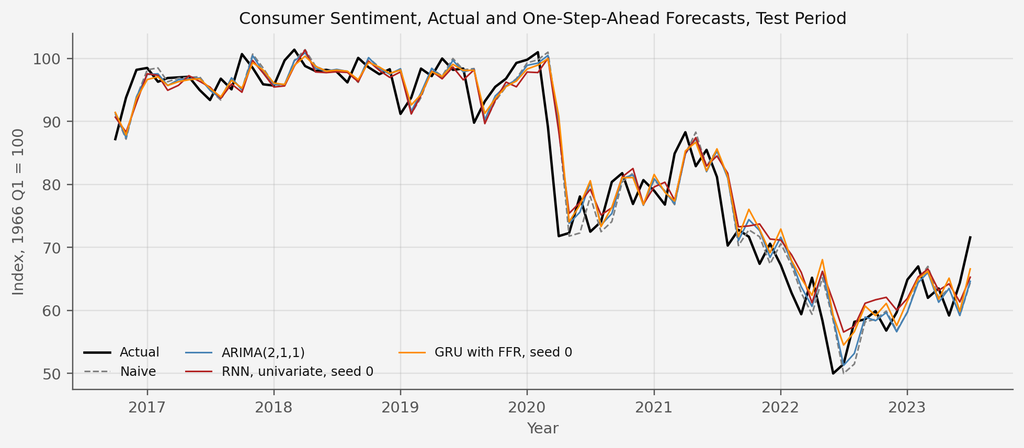

```
Mean squared error, RNN (seed 0): 20.376.  Naive: 20.582.  Standard deviation of the per-month difference in squared error: 13.195 over 82 months.
```

The nine forecasts are within 6% of one another, and the naive forecast is in the middle of them. The univariate `RNN` and `LSTM` have test RMSEs of 4.538 and 4.539 index points against 4.537 for the naive forecast, and the `GRU` 4.558; the differences among the three networks are within their seed-to-seed standard deviations of 0.02 to 0.04. The two ARIMA models are the most accurate, `ARIMA(2,1,1)` at 4.476 and `ARIMAX(2,1,1)` with the policy rate at 4.463, 1.4% and 1.6% below the naive forecast. The gap between the `RNN` and the naive forecast is far smaller than the month-to-month variation in that gap: mean squared errors of 20.38 and 20.58, a difference of 0.21, against a standard deviation of 13.2 in the monthly difference over 82 months. Nothing here separates the network from assuming no change.

Adding the Federal Funds Rate as a second input makes the `RNN` and `LSTM` worse, by 4% and 3% of RMSE, and leaves the `GRU` unchanged, 4.541 against 4.558. The training RMSE falls in each case, from 3.76 to 3.60 for the `RNN`, so the extra input is fitted in the training period and does not transfer: with a correlation between the two series of 0.03 in changes, what the network learns from the policy rate is noise. In the ARIMA framework the policy rate is worth 0.013 of RMSE, a gain too small to distinguish from zero on 82 months.

The figure shows why the forecasts are so alike. Sentiment moves in steps of a few points with occasional jumps, the 17-point fall of April 2020 and the 11-point falls of March 2020 and August 2021, and no model anticipates the jumps. Between them, every model’s forecast is close to last month’s value, with the ARIMA models adding a small correction for the mean reversion in the differenced series. The test-period RMSE of about 4.5 points is the standard deviation of the monthly change itself, which is what a one-step forecast of a random-walk-like series will approach.

## Multi-Step Forecasts

RMSE of Recursive Forecasts by Horizon, 71 Origins from October 2016 to August 2022; Networks Univariate, Seed 0

| Model | h = 1 | h = 3 | h = 6 | h = 12 |
| --- | --- | --- | --- | --- |
| RNN | 4.64 | 7.41 | 9.42 | 12.28 |
| LSTM | 4.70 | 7.59 | 9.75 | 12.59 |
| GRU | 4.73 | 7.80 | 10.05 | 13.16 |
| Naive | 4.61 | 7.44 | 9.59 | 13.05 |
| ARIMA(2,1,1) | 4.56 | 7.33 | 9.43 | 12.63 |

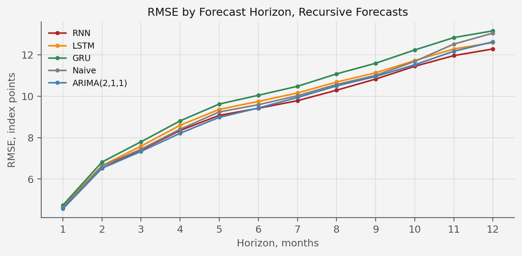

## Deep Learning and Linear Models

On this series the recurrent networks match the linear models and do not improve on them. Three features of the problem explain that. The sample is small by the standards of deep learning, 453 training windows, so a network with one to four thousand parameters is estimated from fewer examples than it has weights, and early stopping at 50 to 180 epochs is what prevents it from fitting the training set. The series is nearly a random walk at monthly frequency, so the best one-step forecast is close to the last value and there is little nonlinear structure for a network to find; the ARIMA’s advantage comes from a linear correction the networks could represent but do not learn reliably. And the test period contains a shock, the pandemic, whose size has no precedent in the training data, which penalises every method equally.

The networks also cost more to use. Each requires a choice of window length, units, optimiser, learning rate, batch size and stopping rule, and its result varies with the seed by up to 0.08 points of RMSE; the ARIMA is specified by three integers chosen by AIC and is the same every time. The `RNN`, the simplest network, is the best of the three here and the one whose training is fastest, which is consistent with the data supporting only a small amount of structure. Where recurrent networks earn their cost is on long, high-frequency series with nonlinear dynamics or many inputs; a 547-month survey index is not that case.

The policy rate does not help either model class predict sentiment a month ahead. This is consistent with the ARIMAX finding for inflation: the policy rate’s effect on households operates through channels, credit conditions, employment, prices, that take longer than a month and that a direct regression on the rate does not capture.

## Summary

Retained Results

| Item | Result |
| --- | --- |
| Target | Consumer sentiment, monthly, 1978–2023, 547 observations |
| Test period | October 2016 to July 2023, 82 months, one step ahead |
| Networks | RNN, LSTM, GRU; one layer of 32 units, Adam, early stopping |
| Inputs | Previous 12 months of sentiment; or of sentiment and the Federal Funds Rate |
| Seeds | Five per model; RMSE reported as mean, s.d. 0.02–0.08 |
| Best network, one step | RNN, univariate: RMSE 4.54 (naive 4.54) |
| Best model, one step | ARIMAX(2,1,1) with FFR: RMSE 4.46; ARIMA(2,1,1): 4.48 |
| Best model, twelve steps | RNN: RMSE 12.3 (naive 13.1, ARIMA 12.6) |
| Federal Funds Rate | Adds nothing to one-step accuracy in either model class |
| RNN against naive, one step | Mean squared error 20.38 against 20.58; no separation |

### What the Section Found

Consumer sentiment is a persistent series whose month-to-month changes are close to unpredictable, and every method tested, from the naive forecast to a 4,500-parameter `LSTM`, produces one-step-ahead errors of about 4.5 index points on the 2016–2023 test period. The ordering is naive ≈ networks > ARIMA by margins of 1 to 2%, with the ARIMA’s advantage coming from a small mean-reversion term. At twelve months the `RNN` is marginally the best, 6% below the naive forecast. No difference in this section is statistically distinguishable from zero.

The Federal Funds Rate has no predictive value for sentiment at a one-month horizon. It lowers the ARIMA’s RMSE by 0.3% and raises the `RNN`’s and `LSTM`’s by 3 to 4%; its correlation with sentiment is −0.04 in levels and 0.03 in changes. This is the third section of the study to find that the policy rate’s contemporaneous or short-lag relationship with a target is weak or absent, after the inflation regression and the dollar-return equation, and the same reason applies: the rate responds to the economy and acts on it with a lag.

### Model Choice

For this series the linear models are the right tool and the networks are a check on them. A recurrent network is a flexible function of the last twelve observations, and on a series where the best forecast is close to the last observation the flexibility is not used. The comparison is fair to the networks, with standardisation by training statistics, early stopping on a held-out set, five seeds and a deterministic configuration, and it would need a longer or richer series to come out differently. If the study were extended, a network with inputs beyond sentiment and the policy rate, such as unemployment, inflation and equity returns, would be the natural next test, since the multivariate case is where recurrent networks have an architectural advantage over ARIMAX.

### Limitations

The test period is 82 months and includes one extreme event, so the RMSE ranking is sensitive to a few observations; the differences between methods are far smaller than the variation in the monthly errors. The networks were tuned only lightly, with one architecture, one window length and one learning rate, and a search over those settings could change the margins, though not, on this evidence, the conclusion. The recursive multi-step forecasts of the networks use the seed-0 models only. The ARIMA order was chosen once on the training period and held fixed while the coefficients were re-estimated each month; the networks were not re-estimated during the test period, which favours the ARIMA slightly at the one-step horizon. The finding that the Federal Funds Rate adds nothing is a statement about a one-month horizon and about the contemporaneous and twelve-month-lagged rate as inputs; it does not rule out an effect on sentiment at the longer lags at which the macroeconomic vector autoregression finds the policy rate reaching output and unemployment.

## References

Cho, Kyunghyun, Bart van Merriënboer, Caglar Gulcehre, et al. 2014. “Learning Phrase Representations Using RNN Encoder–Decoder for Statistical Machine Translation.” *Proceedings of the 2014 Conference on Empirical Methods in Natural Language Processing*, 1724–34. https://doi.org/10.3115/v1/D14-1179.

Hochreiter, Sepp, and Jürgen Schmidhuber. 1997. “Long Short-Term Memory.” *Neural Computation* 9 (8): 1735–80. https://doi.org/10.1162/neco.1997.9.8.1735.